# Lab 13: Relational Databases

Statistical Computing, 36-350

Week of Monday November 18, 2019

Name: Xi Chen Andrew ID: xc3 Collaborated with: anwenh

This lab is to be done in class (completed outside of class if need be). You can collaborate with your classmates, but you must identify their names above, and you must submit **your own** lab as an knitted HTML file on Canvas, by Sunday 11:59pm, this week.

**This week’s agenda**: practicing SQLite queries, performing simple computations and joins, and testing our understanding by writing equivalent R code for these database manipulations. Make sure to complete your weekly **check-in** (which can be done by coming to lecture, recitation, lab, or any office hour), as this will count a small number of points towards your lab score.

# Lahman baseball database

Thanks to Sean Lahman, extensive baseball data is freely available from the 1871 season all the way to the current season. We’re going ot use a SQLite version of the baseball database put together by Jeff Knecht, at https://github.com/jknecht/baseball-archive-sqlite. The most recent SQLite database was recently updated to include the 2016 season. It has been posted to the class website at http://www.stat.cmu.edu/~ryantibs/statcomp/data/lahman2016.sqlite. Download this file (it’s about 50 MB) and save it in the working directory for your lab.

# Practice with SQL data extraction

- **1a.** Install the packages `DBI`, `RSQLite` if you haven’t done so already, and load them into your R session. Using `dbDriver()`, `dbConnect()`, set up a connection called `con` the SQLite database stored in lahman2016.sqlite. Then, use `dbListTables()` to list the tables in the database.

```r
library(DBI)
library(RSQLite)
drv = dbDriver("SQLite")
con = dbConnect(drv, dbname="lahman2016.sqlite")
dbListTables(con)
```

```
##  [1] "AllstarFull"         "Appearances"         "AwardsManagers"
##  [4] "AwardsPlayers"       "AwardsShareManagers" "AwardsSharePlayers"
##  [7] "Batting"             "BattingPost"         "CollegePlaying"
## [10] "Fielding"            "FieldingOF"          "FieldingOFsplit"
## [13] "FieldingPost"        "HallOfFame"          "HomeGames"
## [16] "Managers"            "ManagersHalf"        "Master"
## [19] "Parks"               "Pitching"            "PitchingPost"
## [22] "Salaries"            "Schools"             "SeriesPost"
## [25] "Teams"               "TeamsFranchises"     "TeamsHalf"
```

- **1b.** Using `dbReadTable()`, grab the table named “Batting” and save it as a data frame in your R session, called `batting`. Check that `batting` is indeed a data frame, and that it has dimension 102816 x 24.

```r
batting <- dbReadTable(con, "Batting")
class(batting)
```

```
## [1] "data.frame"
```

```r
dim(batting)
```

```
## [1] 102816     24
```

- **1c.** Remove `eval=FALSE` from the preamble in the R code chunks below. Then, after each SQL query (each call to `dbGetQuery()`), explain in words what is being extracted, and write one line of base R code (sometimes you might need two lines) to get the same result using the `batting` data frame.

```r
dbGetQuery(con, paste("SELECT playerID, yearID, AB, H, HR",
                      "FROM Batting",
                      "ORDER BY yearID",
                      "LIMIT 10"))

head(batting[order(batting$yearID),c("playerID", "yearID", "AB", "H", "HR")],10)
```

[output not shown]

We first extract columns: playerID, yearID, AB, H, HR from batting, then sort the dataframe by yearID, then get the first 10 lines.

```r
dbGetQuery(con, paste("SELECT playerID, yearID, AB, H, HR",
                      "FROM Batting",
                      "ORDER BY HR DESC",
                      "LIMIT 10"))

head(batting[order(batting$HR, decreasing = TRUE),c("playerID", "yearID", "AB", "H", "HR")],10)
```

[output not shown]

We first extract columns: playerID, yearID, AB, H, HR from batting, then sort the dataframe by descending order of HR, then get the first 10 lines.

```r
dbGetQuery(con, paste("SELECT playerID, yearID, AB, H, HR",
                      "FROM Batting",
                      "WHERE HR > 55",
                      "ORDER BY HR DESC"))

temp <- batting[which(batting$HR > 55),c("playerID", "yearID", "AB", "H", "HR")]
head(temp[order(temp$HR, decreasing = TRUE), ],10)
```

[output not shown]

```r
dbGetQuery(con, paste("SELECT playerID, yearID, AB, H, HR",
                      "FROM Batting",
                      "WHERE yearID >= 1990 AND yearID <= 2000",
                      "ORDER BY HR DESC",
                      "LIMIT 10"))

temp2 <- batting[which(batting$yearID >= 1990 & batting$yearID <= 2000),c("playerID", "yearID", "AB", "H", "HR")]
head(temp2[order(temp2$HR, decreasing = TRUE), ],10)
```

[output not shown]

We first extract columns: playerID, yearID, AB, H, HR from batting, then find all the rows with yearID between 1990 and 2000. After that, sort the dataframe by descending order of HR, then get the first 10 lines.

- **1d.** Replicate the computations in the last question on more time, now using `dplyr` verbs and pipes.

```r
library(tidyverse)
dbGetQuery(con, paste("SELECT playerID, yearID, AB, H, HR",
                      "FROM Batting",
                      "WHERE yearID >= 1990 AND yearID <= 2000",
                      "ORDER BY HR DESC",
                      "LIMIT 10"))
```

```
##     playerID yearID  AB   H HR
## 1  mcgwima01   1998 509 152 70
## 2   sosasa01   1998 643 198 66
## 3  mcgwima01   1999 521 145 65
## 4   sosasa01   1999 625 180 63
## 5  griffke02   1997 608 185 56
## 6  griffke02   1998 633 180 56
## 7  mcgwima01   1996 423 132 52
## 8  fieldce01   1990 573 159 51
## 9  anderbr01   1996 579 172 50
## 10 belleal01   1995 546 173 50
```

```r
batting %>%
  select(., playerID, yearID, AB, H, HR) %>%
  filter(., yearID >=1990 & yearID <=2000) %>%
  arrange(desc(HR)) %>%
  head(10)
```

```
##     playerID yearID  AB   H HR
## 1  mcgwima01   1998 509 152 70
## 2   sosasa01   1998 643 198 66
## 3  mcgwima01   1999 521 145 65
## 4   sosasa01   1999 625 180 63
## 5  griffke02   1997 608 185 56
## 6  griffke02   1998 633 180 56
## 7  mcgwima01   1996 423 132 52
## 8  fieldce01   1990 573 159 51
## 9  anderbr01   1996 579 172 50
## 10 belleal01   1995 546 173 50
```

# Practice with SQL computations

- **2a.** As before, remove `eval=FALSE` from the preamble in the following R code chunks. Then, after each SQL query, explain in words what is being extracted, and write one line of base R code to get the same result using the `batting` data frame. Hint: often you’ll have to use `na.rm=TRUE` to deal with NA values, for example `mean(x, na.rm=TRUE)` computes the mean of a vector `x` after removing any NA values.

```r
dbGetQuery(con, paste("SELECT AVG(HR)",
                      "FROM Batting"))
```

```
##    AVG(HR)
## 1 2.813599
```

```r
mean(batting$HR, na.rm=TRUE)
```

```
## [1] 2.813599
```

This is computing the mean of HR of the batting dataframe.

```r
dbGetQuery(con, paste("SELECT SUM(HR)",
                      "FROM Batting"))
```

```
##   SUM(HR)
## 1  289283
```

```r
sum(batting$HR, na.rm=TRUE)
```

```
## [1] 289283
```

This is computing the sum of HR column.

```r
dbGetQuery(con, paste("SELECT playerID, yearID, teamID, MAX(HR)",
                      "FROM Batting"))
```

```
##    playerID yearID teamID MAX(HR)
## 1 bondsba01   2001    SFN      73
```

```r
batting[which(batting$HR == max(batting$HR)),c("playerID", "yearID", "teamID", "HR")]
```

```
##       playerID yearID teamID HR
## 8376 bondsba01   2001    SFN 73
```

Extract columns playerID, yearID, teamID, HR and only get the rows where HR is the maximum.

```r
dbGetQuery(con, paste("SELECT AVG(HR)",
                      "FROM Batting",
                      "WHERE yearID >= 1990"))
```

```
##    AVG(HR)
## 1 3.585889
```

```r
mean(batting[which(batting$yearID >=1990),]$HR, na.rm = T)
```

```
## [1] 3.585889
```

Extract the rows where yearID is larger than or equal to 1990 and get the average of HR.

- **2b.** Again, after each SQL query explain in words what is being extracted, and write one line (or two lines) of R code to get the same result using the `batting` data frame. You may use base R, `plyr`, `dplyr`, pipes, or whatever means you want.

```r
dbGetQuery(con, paste("SELECT teamID, AVG(HR)",
                      "FROM Batting",
                      "WHERE yearID >= 1990",
                      "GROUP BY teamID",
                      "LIMIT 5"))
```

```
##   teamID  AVG(HR)
## 1    ANA 3.928783
## 2    ARI 3.610227
## 3    ATL 3.822374
## 4    BAL 3.958401
## 5    BOS 3.621142
```

```r
batting %>%
filter(., yearID >= 1990) %>%
select(teamID, HR) %>%
group_by(teamID) %>%
summarise(HR = mean(HR, na.rm = T)) %>%
head(5)
```

```
## # A tibble: 5 x 2
##   teamID    HR
##   <chr>  <dbl>
## 1 ANA     3.93
## 2 ARI     3.61
## 3 ATL     3.82
## 4 BAL     3.96
## 5 BOS     3.62
```

first, get the rows with yearID >= 1990, then select columns teamID and HR and group by teamID. After that, calculate the average of HR and display the first 5 rows.

```r
dbGetQuery(con, paste("SELECT teamID, AVG(HR)",
                      "FROM Batting",
                      "WHERE yearID < 1960",
                      "GROUP BY teamID",
                      "ORDER BY AVG(HR) DESC",
                      "LIMIT 5"))
```

```
##   teamID  AVG(HR)
## 1    ML1 5.029412
## 2    SFN 4.616438
## 3    LAN 3.950617
## 4    NYP 3.882353
## 5    BSP 3.176471
```

```r
batting %>%
filter(., yearID < 1960) %>%
select(teamID, HR) %>%
group_by(teamID) %>%
summarise(HR = mean(HR, na.rm = T)) %>%
arrange(., desc(HR)) %>%
head(5)
```

```
## # A tibble: 5 x 2
##   teamID    HR
##   <chr>  <dbl>
## 1 ML1     5.03
## 2 SFN     4.62
## 3 LAN     3.95
## 4 NYP     3.88
## 5 BSP     3.18
```

first, get the rows with yearID < 1960, then select columns teamID and HR and group by teamID. After that, calculate the average of HR, sort the dataframe by descending order of HR and display the first 5 rows.

```r
dbGetQuery(con, paste("SELECT teamID, yearID, AVG(HR)",
                      "FROM Batting",
                      "WHERE yearID == 1991 OR yearID == 1992",
                      "GROUP BY teamID, yearID",
                      "ORDER BY AVG(HR) DESC",
                      "LIMIT 15"))
```

```
##    teamID yearID  AVG(HR)
## 1     DET   1992 5.352941
## 2     DET   1991 5.097561
## 3     CIN   1991 4.100000
## 4     CHN   1991 4.076923
## 5     NYA   1992 4.075000
## 6     TOR   1992 4.075000
## 7     BAL   1991 4.047619
## 8     MIN   1991 4.000000
## 9     BAL   1992 3.894737
## 10    NYA   1991 3.675000
## 11    CHA   1991 3.657895
## 12    TEX   1991 3.612245
## 13    SDN   1992 3.461538
## 14    OAK   1991 3.456522
## 15    SFN   1991 3.439024
```

```r
batting %>%
filter(., yearID == 1991 | yearID == 1992) %>%
select(teamID, yearID, HR) %>%
group_by(teamID, yearID) %>%
summarise(HR = mean(HR, na.rm = T)) %>%
arrange(., desc(HR)) %>%
head(15)
```

```
## # A tibble: 15 x 3
## # Groups:   teamID [12]
##    teamID yearID    HR
##    <chr>   <int> <dbl>
##  1 DET      1992  5.35
##  2 DET      1991  5.10
##  3 CIN      1991  4.1
##  4 CHN      1991  4.08
##  5 NYA      1992  4.08
##  6 TOR      1992  4.08
##  7 BAL      1991  4.05
##  8 MIN      1991  4
##  9 BAL      1992  3.89
## 10 NYA      1991  3.68
## 11 CHA      1991  3.66
## 12 TEX      1991  3.61
## 13 SDN      1992  3.46
## 14 OAK      1991  3.46
## 15 SFN      1991  3.44
```

first, get the rows with yearID equaling either 1991 or 1992, then select columns teamID, yearID and HR and group by teamID and yearID. After that, calculate the average of HR, sort the dataframe by descending order of HR and display the first 15 rows.

# More practice with computations

- **3a.** Use a SQL query on the “Batting” table to calculate each player’s average number of hits (`H`) over the seasons they played, and display the players with the 10 highest hit averages, along with their hit averages. Hint: `AVG()`, `GROUP BY`, `ORDER BY`.

```r
dbGetQuery(con, paste("SELECT playerID, AVG(H) as avgH",
                      "FROM Batting",
                      "GROUP BY playerID",
                      "ORDER BY avgH DESC",
                      "LIMIT 10"))
```

```
##     playerID     avgH
## 1  puckeki01 192.0000
## 2   canoro01 184.1667
## 3  cabremi01 179.9286
## 4  abreujo02 179.0000
## 5  suzukic01 178.2353
## 6  burkeje01 178.1250
## 7  pujolal01 176.5625
## 8  sislege01 175.7500
## 9   cobbty01 174.5417
## 10 altuvjo01 174.3333
```

- **3b.** Calculate the same as in the last question, but now display all players whose hit averages are above 170. Hint: `HAVING`.

```r
dbGetQuery(con, paste("SELECT playerID, AVG(H) as avgH",
                      "FROM Batting",
                      "GROUP BY playerID",
                      "HAVING avgH > 170",
                      "ORDER BY avgH DESC"
                      ))
```

```
##     playerID     avgH
## 1  puckeki01 192.0000
## 2   canoro01 184.1667
## 3  cabremi01 179.9286
## 4  abreujo02 179.0000
## 5  suzukic01 178.2353
## 6  burkeje01 178.1250
## 7  pujolal01 176.5625
## 8  sislege01 175.7500
## 9   cobbty01 174.5417
## 10 altuvjo01 174.3333
## 11 jeterde01 173.2500
## 12 markani01 171.7273
## 13 ashburi01 171.6000
## 14 dimagjo01 170.3077
## 15  rosepe01 170.2400
```

- **3c.** Calculate the same as in the last question, but now display for all players with hit averages above 170—-in addition to the player’s ID and his batting average—the last year in which each player played.

```r
dbGetQuery(con, paste("SELECT playerID, AVG(H) as avgH, MAX(yearID) as lastyear",
                      "FROM Batting",
                      "GROUP BY playerID",
                      "HAVING avgH > 170",
                      "ORDER BY avgH DESC"
                      ))
```

```
##     playerID     avgH lastyear
## 1  puckeki01 192.0000     1995
## 2   canoro01 184.1667     2016
## 3  cabremi01 179.9286     2016
## 4  abreujo02 179.0000     2016
## 5  suzukic01 178.2353     2016
## 6  burkeje01 178.1250     1905
## 7  pujolal01 176.5625     2016
## 8  sislege01 175.7500     1930
## 9   cobbty01 174.5417     1928
## 10 altuvjo01 174.3333     2016
## 11 jeterde01 173.2500     2014
## 12 markani01 171.7273     2016
## 13 ashburi01 171.6000     1962
## 14 dimagjo01 170.3077     1951
## 15  rosepe01 170.2400     1986
```

# Practice with SQL join operations

- **4a.** Using `JOIN`, merge the “Batting” and “Salaries” tables based on matching the `yearID`, `playerID` pairs. Display the year, player, salary, and number of hits for the first 10 records.

```r
salary <- dbReadTable(con, "Salaries")
dbGetQuery(con, paste("SELECT s.yearID,s.playerID, salary, H",
                      "FROM Batting b",
                      "JOIN Salaries s",
                      "ON s.yearID = b.yearID AND b.playerID = s.playerID",
                      "LIMIT 10"))
```

```
##    yearID  playerID salary   H
## 1    1985 barkele01 870000   0
## 2    1985 bedrost01 550000   5
## 3    1985 benedbr01 545000  42
## 4    1985  campri01 633333   3
## 5    1985 ceronri01 625000  61
## 6    1985 chambch01 800000  40
## 7    1985 dedmoje01 150000   1
## 8    1985 forstte01 483333   0
## 9    1985 garbege01 772000   1
## 10   1985 harpete01 250000 130
```

- **4b.** Building off of the code from the end of lecture, which does something similar, compute the average salaries for the players with the top 10 highest hit averages.

```r
dbGetQuery(con, paste("SELECT playerID, AVG(H) as avgHit, AVG(salary) as avgSalary",
                      "FROM Batting JOIN Salaries USING(yearID, playerID)",
                      "GROUP BY playerID",
                      "ORDER BY Avg(H) DESC",
                      "LIMIT 10"))
```

```
##     playerID   avgHit avgSalary
## 1  altuvjo01 197.0000   1685240
## 2  puckeki01 194.4545   2708182
## 3  bettsmo01 194.0000    540250
## 4  seageco01 193.0000    510000
## 5   canoro01 186.8182  11806527
## 6  lindofr01 182.0000    540300
## 7  jeterde01 181.7368  13927268
## 8  cabremi01 179.9286  13457902
## 9  abreujo02 179.0000   9110889
## 10 suzukic01 178.2353  10713617
```

- **4c.** Compute the hit averages for the players with the top 10 highest salaries. Hint: this should only require a very small tweak to the code you wrote for the last question.

```r
dbGetQuery(con, paste("SELECT playerID, AVG(H) as avgHit, AVG(salary) as avgSalary",
                      "FROM Batting JOIN Salaries USING(yearID, playerID)",
                      "GROUP BY playerID",
                      "ORDER BY Avg(salary) DESC",
                      "LIMIT 10"))
```

```
##     playerID      avgHit avgSalary
## 1  tanakma01   0.3333333  22000000
## 2  rodrial01 141.5909091  18109830
## 3  howarry01 130.9000000  15525500
## 4  teixema01 116.3750000  14735938
## 5  jeterde01 181.7368421  13927268
## 6  fieldpr01 148.0000000  13901318
## 7  sabatcc01   1.6666667  13642857
## 8  hamelco01   9.2727273  13536364
## 9  cabremi01 179.9285714  13457902
## 10 mauerjo01 140.4615385  13232692
```

- **4d.** Using the “Fielding” table, list the 10 worst (highest) number of errors (`E`) committed by a player in a season, only considering the year 1990 and later. In addition to the number of errors, list the year and player ID for each record.

```r
dbGetQuery(con, paste("SELECT playerID, yearID, E as numErrors",
                      "FROM FIELDING",
                      "WHERE yearID >= 1990",
                      "ORDER BY E DESC",
                      "LIMIT 10"))
```

```
##     playerID yearID numErrors
## 1  offerjo01   1992        42
## 2  offerjo01   1993        37
## 3  valenjo03   1996        37
## 4  valenjo03   2000        36
## 5  carusmi01   1998        35
## 6  offerjo01   1995        35
## 7  semiema01   2015        35
## 8  desmoia01   2010        34
## 9  reynoma01   2008        34
## 10 cordewi01   1993        33
```

- **4e.** By appropriately merging the “Fielding” and “Salaries” tables, list the salaries for each record that you extracted in the last question. Then, answer the following question: what was the highest salary paid to a player who made at least 30 errors in a season, after 1990?

```r
dbGetQuery(con, paste("SELECT f.playerID, f.yearID, E as numErrors, salary",
                      "FROM FIELDING f
                      LEFT JOIN SALARIES s
                      USING (playerID, yearID)",
                      "WHERE f.yearID >= 1990",
                      "ORDER BY E DESC",
                      "LIMIT 10"))
```

```
##     playerID yearID numErrors  salary
## 1  offerjo01   1992        42  135000
## 2  offerjo01   1993        37  300000
## 3  valenjo03   1996        37  300000
## 4  valenjo03   2000        36 1320000
## 5  carusmi01   1998        35  170000
## 6  offerjo01   1995        35 1600000
## 7  semiema01   2015        35  510000
## 8  desmoia01   2010        34  400000
## 9  reynoma01   2008        34  396500
## 10 cordewi01   1993        33  126500
```

```r
dbGetQuery(con, paste("SELECT f.playerID, f.yearID, E as numErrors, max(salary)",
                      "FROM FIELDING f
                      LEFT JOIN SALARIES s
                      USING (playerID, yearID)",
                      "WHERE f.yearID >= 1990 AND numErrors >= 30",
                      "ORDER BY numErrors DESC"))
```

```
##    playerID yearID numErrors max(salary)
## 1 renteed01   2005        30       8e+06
```

The highest salary paid to a player who made at least 30 errors in a season after 1990 is 8000000.

# All about the money

- **5a.** Use a SQL query on the “Salaries” table to compute the payroll (total of salaries) for each team in the year 2010, and display the 3 teams with the highest payrolls. Do the same, but display the 3 teams with the lowest payroll (ouch!).

```r
dbGetQuery(con, paste("SELECT teamID, SUM(salary) as payroll",
                      "FROM SALARIES",
                      "WHERE yearID = 2010",
                      "GROUP BY teamID",
                      "ORDER BY payroll DESC",
                      "LIMIT 3"))
```

```
##   teamID   payroll
## 1    NYA 206333389
## 2    BOS 162447333
## 3    CHN 146609000
```

```r
dbGetQuery(con, paste("SELECT teamID, SUM(salary) as payroll",
                      "FROM SALARIES",
                      "WHERE yearID = 2010",
                      "GROUP BY teamID",
                      "ORDER BY payroll ASC",
                      "LIMIT 3"))
```

```
##   teamID  payroll
## 1    PIT 34943000
## 2    SDN 37799300
## 3    TEX 55250544
```

- **5b.** Use a SQL query to compute the total payroll for each team, added up over the years between 1985 and 2016. Hint: `dbGetQuery()` actually returns a data frame. You should have a data frame of dimension 46 x 2, and the 2 columns should display the team ID and the payroll. Check that your data frame has the right dimensions and display its first 10 rows. Then, answer: what team has the highest total payroll? The lowest payroll? Where do the Pirates rank?

```r
payrolls <- dbGetQuery(con, paste("SELECT teamID, SUM(salary) as payroll",
                      "FROM SALARIES",
                      "WHERE yearID >= 1985 and yearID <= 2016",
                      "GROUP BY teamID"))
dim(payrolls)
```

```
## [1] 46  2
```

```r
head(payrolls, 10)
```

```
##    teamID    payroll
## 1     ANA  468091973
## 2     ARI 1359248291
## 3     ATL 2023226325
## 4     BAL 1907108327
## 5     BOS 2802350096
## 6     CAL  271978930
## 7     CHA 1812238843
## 8     CHC  154067668
## 9     CHN 1975712625
## 10    CHW  112998667
```

```r
payrolls[which(payrolls$payroll == max(payrolls$payroll)),]$teamID
```

```
## [1] "NYA"
```

```r
payrolls[which(payrolls$payroll == min(payrolls$payroll)),]$teamID
```

```
## [1] "TBR"
```

NYA has the highest total payroll. TBR has the lowest total payroll.

- **5c.** Use a SQL query to compute the payroll for each team, separately for each year in between 1985 and 2016. Hint: `GROUP BY` can take two arguments, separated by a comma. You should have a data frame of dimension 918 x 3, and the 3 columns should be display the team ID, year, and payroll. Check that your data frame has the proper dimensions, and display its last 10 rows.

```r
payrolls5c <- dbGetQuery(con, paste("SELECT teamID, yearID, SUM(salary) as payroll",
                      "FROM SALARIES",
                      "WHERE yearID >= 1985 and yearID <= 2016",
                      "GROUP BY teamID, yearID"))

dim(payrolls5c)
```

```
## [1] 918   3
```

```r
tail(payrolls5c, 10)
```

```
##     teamID yearID   payroll
## 909    PHI   2016  58980000
## 910    PIT   2016 103778833
## 911    SDP   2016 101424814
## 912    SEA   2016 135683339
## 913    SFG   2016 172253778
## 914    STL   2016 143053500
## 915    TBR   2016  57097310
## 916    TEX   2016 176038723
## 917    TOR   2016 138701700
## 918    WSN   2016 141652646
```

- **5d.** Plot the Pittsburgh Pirates’ payroll over time (i.e., over the years 1985 to 2016), with appropriately labeled axes and an appropriate title. What is the trend that you see?

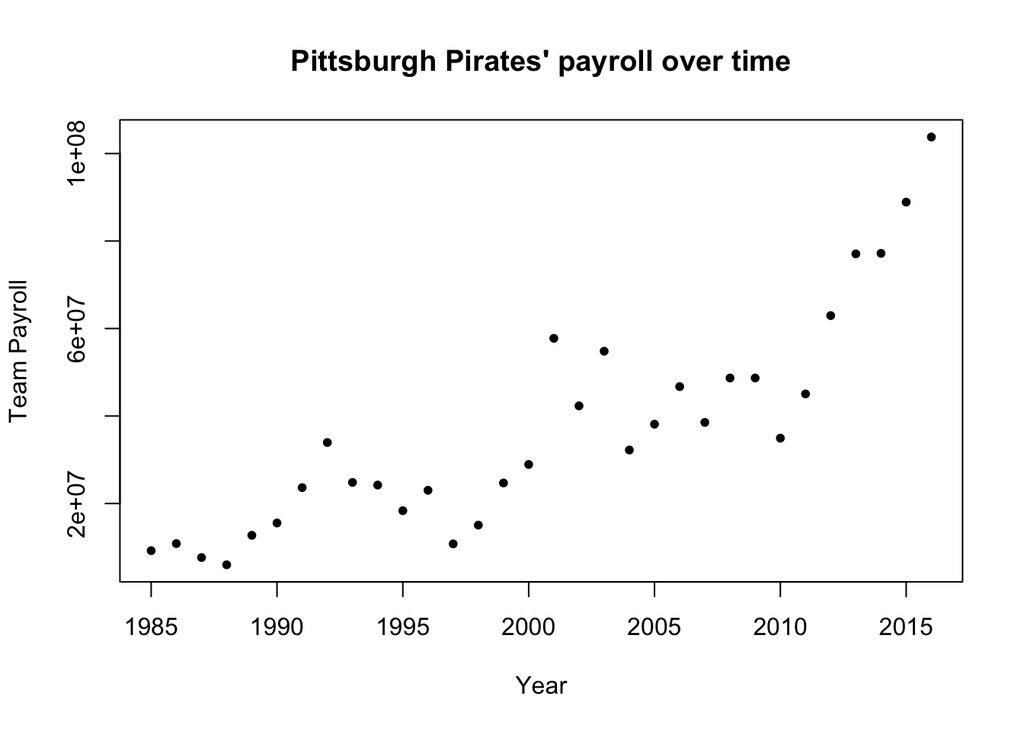

```r
pitpayroll <- payrolls5c[which(payrolls5c$teamID == "PIT"),]
plot(x = pitpayroll$yearID, y = pitpayroll$payroll, xlab = "Year", ylab = "Team Payroll", main = "Pittsburgh Pirates' payroll over time", pch = 20)
```

The payroll for Pittsburgh Pirate is increasing in general with temporary decreases around 1993 to 1997 and around 2002 to 2010.

- **Challenge.** On a single plot, display the payrolls over time (i.e., over the years 1985 to 2016) for 8 teams of your choosing. Make sure that their payroll curves are distinguishable (by color, line type, some combo, you choose). Make sure that the y limit is properly set (so the extremes of all curves are properly contained within the plotting region). Use appropriately labeled axes, an appropriate title, and an informative legend.

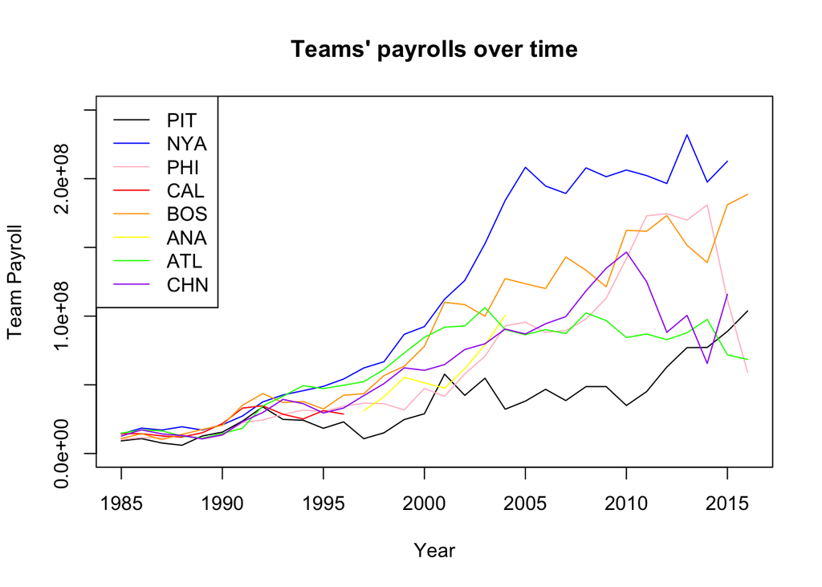

```r
plot(x = pitpayroll$yearID, y = pitpayroll$payroll, xlab = "Year", ylab = "Team Payroll", main = "Teams' payrolls over time", pch = 20, ylim = c(0, 250000000), type = "l")
lines(payrolls5c[which(payrolls5c$teamID == "NYA"),]$yearID, payrolls5c[which(payrolls5c$teamID == "NYA"),]$payroll, col = "blue", pch = 20)
lines(payrolls5c[which(payrolls5c$teamID == "PHI"),]$yearID, payrolls5c[which(payrolls5c$teamID == "PHI"),]$payroll, col = "pink", pch = 20)
lines(payrolls5c[which(payrolls5c$teamID == "CAL"),]$yearID, payrolls5c[which(payrolls5c$teamID == "CAL"),]$payroll, col = "red", pch = 20)
lines(payrolls5c[which(payrolls5c$teamID == "BOS"),]$yearID, payrolls5c[which(payrolls5c$teamID == "BOS"),]$payroll, col = "orange", pch = 20)
lines(payrolls5c[which(payrolls5c$teamID == "ANA"),]$yearID, payrolls5c[which(payrolls5c$teamID == "ANA"),]$payroll, col = "yellow", pch = 20)
lines(payrolls5c[which(payrolls5c$teamID == "ATL"),]$yearID, payrolls5c[which(payrolls5c$teamID == "ATL"),]$payroll, col = "green", pch = 20)
lines(payrolls5c[which(payrolls5c$teamID == "CHN"),]$yearID, payrolls5c[which(payrolls5c$teamID == "CHN"),]$payroll, col = "purple", pch = 20)
legend("topleft", legend=c("PIT", "NYA", "PHI", "CAL", "BOS", "ANA", "ATL", "CHN"),
       col=c("black", "blue", "pink", "red", "orange", "yellow", "green", "purple"), lty=1)
```

- **Challenge.** To make these plots more sensible, we need to adjust for inflation. Find data on the average consumer price index (CPI) over the years 1985 to 2016, and use this to adjust the payrolls for inflation and reproduce your plot from Q2d. Comment on the changes.

# Batting averages (optional)

- **6a.** Use a SQL query to calculate the top 10 best batting averages achieved by a player in any season after 1940. Note: batting average is the number of hits (`H`) divided by number of at bats (`AB`) achieved by a player in a given season, but (let’s say) it is only defined for players that have at least 400 at bats in that season. Your resulting data frame from the SQL query should be 10 x 3, with the 3 columns displaying the playerID, yearID, and batting average.

```r
df6a <- dbGetQuery(con, paste("SELECT playerID, yearID, H/AB as batting_average",
                      "FROM BATTING",
                      "WHERE yearID > 1940 and AB > 400",
                      "LIMIT 10"))
dim(df6a)
```

```
## [1] 10  3
```

- **6b.** Compute batting averages as described above, but now plot a histogram of all of these battings averages (aggregated over all players and all seasons after 1940), with an appropriate title. Use a large value of the `breaks` argument to get a good sense of the shape of the histogram. Does this look like a normal distribution to you? What is the estimated mean and the standard deviation? Overlay the normal density curve on top of your histogram, with the appropriate mean and variance, and comment on how it fits. Perform a rigorous hypothesis test for normality of batting averages here; you might consider using `ks.test()`.
- **6c.** For the computed batting averages in the last question, separate out the batting averages before and after 1985. Plot two overlaid histograms, using transparent colors, for the batting averages before and after 1985. Set an appropriate title and informative legend. Do the distributions look different? If so, how? Perform a rigorous hypothesis test for the difference in distributions here; you might again consider using `ks.test()`.
- **6d.** Modifying your last SQL query so that you also extract, in addition to the batting averages, the number of home runs (for all players and all seasons after 1940). Produce a scatterplot of the number of home runs versus the batting average, with appropriate axes labels and an appropriate title. What does the general trend appear to be? Overlay the least squares regression line on top of your plot. What could go wrong with using this regression line to predict a player’s home run total from their batting average?